# Explorative Datenanalyse (EDA) - Teil 1: Datenaufbereitung

Andreas Warntjen

28.2.2021

## Inhalt

- Überblick
- Bibliotheken
- Daten einlesen und Überblick gewinnen
- Einzelne Variablen betrachten
- Fehlende Werte
- Daten filtern
- Re-Kodierung: neue kategorische Variablen bilden
  - Neue kategorische Variable als Hierarchie
  - Binning

In einer explorativen Datenanalyse (EDA) betrachtet man verschiedene deskriptive Statistiken und bi-variate Zusammenhänge, um sich zum einen mit den Daten vertraut zu machen und zum anderen weitere statistische Modellierungen vorzubereiten. In diesem ersten Teil liegt der Fokus darauf, einen Überblick über die Daten zu gewinnen und sie neu zu zuschneiden (Re-Kodierung).

In diesem Bespiel nutzen wir Daten vom World Happiness Report (2019). Sie können hier abgerufen werden: https://worldhappiness.report/ed/2019/

## Bibliotheken

Wir benötigen die folgenden Bibliotheken:

- os: zum Auswählen des Verzeichnes
- numpy: zur Datenmanipulation
- pandas: Datenimport, -manipulation und - analyse

```python
## Bibliotheken importieren

import os
import numpy as np
import pandas as pd
import warnings

## Generelle Einstellungen
warnings.filterwarnings('ignore')
```

## Daten einlesen und Überblick gewinnen

Für CSV- und Excel-Dateien stellt pandas Funktionen zum Einlesen bereit. Ein so eingelesener Datensatz wird in einem Pandas Dataframe gespeichert.

Mit dem Befehl chdir aus dem OS-Modul kann das Arbeitsverzeichnis gewechselt werden. Die Daten liegen in einem Unterverzeichnis "Data".

```python
## Daten einlesen
source_path=".\Data"
source_filename="WHR2019_Chapter2OnlineData.xls"
os.chdir(source_path)
# Default für read_excel ist 1. Worksheet (sheet_name=0) und
# 1. Reihe als Spaltenname (header=0)
df = pd.read_excel(source_filename)
```

Eine Überblick über den Datensatz geben

- das Attribut `shape` (Dimensionen)
- das Attribut `columns` (Spaltennamen)
- die Methode `info()` (Anzahl Beobachtungen, Spaltennamen und Datentypen)
- die Methode `head()` (erste Zeilen)

```python
# Anzahl Zeilen und Spalten
df.shape
```

```
(1704, 26)
```

```python
# Spaltennamen
df.columns
```

```
Index(['Country name', 'Year', 'Life Ladder', 'Log GDP per capita',
       'Social support', 'Healthy life expectancy at birth',
       'Freedom to make life choices', 'Generosity',
       'Perceptions of corruption', 'Positive affect', 'Negative affect',
       'Confidence in national government', 'Democratic Quality',
       'Delivery Quality', 'Standard deviation of ladder by country-year',
       'Standard deviation/Mean of ladder by country-year',
       'GINI index (World Bank estimate)',
       'GINI index (World Bank estimate), average 2000-16',
       'gini of household income reported in Gallup, by wp5-year',
       'Most people can be trusted, Gallup',
       'Most people can be trusted, WVS round 1981-1984',
       'Most people can be trusted, WVS round 1989-1993',
       'Most people can be trusted, WVS round 1994-1998',
       'Most people can be trusted, WVS round 1999-2004',
       'Most people can be trusted, WVS round 2005-2009',
       'Most people can be trusted, WVS round 2010-2014'],
      dtype='object')
```

```python
# Spalten, Datentypen und fehlende Werte
df.info()
```

```
<class 'pandas.core.frame.DataFrame'>
RangeIndex: 1704 entries, 0 to 1703
Data columns (total 26 columns):
 #   Column                                                    Non-Null Count  Dtype
---  ------                                                    --------------  -----
 0   Country name                                              1704 non-null   object
 1   Year                                                      1704 non-null   int64
 2   Life Ladder                                               1704 non-null   float64
 3   Log GDP per capita                                        1676 non-null   float64
 4   Social support                                            1691 non-null   float64
 5   Healthy life expectancy at birth                          1676 non-null   float64
 6   Freedom to make life choices                              1675 non-null   float64
 7   Generosity                                                1622 non-null   float64
 8   Perceptions of corruption                                 1608 non-null   float64
 9   Positive affect                                           1685 non-null   float64
```

[output cut: 18 more lines]

## Einzelne Variablen betrachten

Mit Hilfe von `describe()` können wir uns die Verteilung numerischer Variablen ausgeben lassen. Die Funktion kann auf den gesamten Datensatz (DataFrame) angewendet werden, eine Auswahl oder auf eine einzelne Spalte.

```python
# Zusammenfassung aller numerischen Variablen
df.describe()
```

|  | Year | Life Ladder | Log GDP per capita | Social support | Healthy life expectancy at birth | Freedom to make life choices | Generosity | Perceptions of corruption | Positive affect | Negative affect | ... | GINI index (World Bank estimate) | GINI index (World Bank estimate), average 2000-16 | gini of household income reported in Gallup, by wp5-year | Most people can be trusted, Gallup | Most people can be trusted, WVS round 1981-1984 | Most people can be trusted, WVS round 1989-1993 | Most people can be trusted, WVS round 1994-1998 | Most people can be trusted, WVS round 1999-2004 | Most people can be trusted, WVS round 2005-2009 | Most people can be trusted, WVS round 2010-2014 |
| --- | --- | --- | --- | --- | --- | --- | --- | --- | --- | --- | --- | --- | --- | --- | --- | --- | --- | --- | --- | --- | --- |
| count | 1704.000000 | 1704.000000 | 1676.000000 | 1691.000000 | 1676.000000 | 1675.000000 | 1622.000000 | 1608.000000 | 1685.000000 | 1691.000000 | ... | 643.000000 | 1502.000000 | 1335.000000 | 180.000000 | 125.000000 | 220.000000 | 618.000000 | 491.000000 | 630.000000 | 671.000000 |
| mean | 2012.332160 | 5.437155 | 9.222456 | 0.810570 | 63.111971 | 0.733829 | 0.000079 | 0.751315 | 0.709368 | 0.265679 | ... | 0.370000 | 0.385438 | 0.447771 | 0.226295 | 0.390480 | 0.283925 | 0.249574 | 0.268070 | 0.264336 | 0.237493 |
| std | 3.688072 | 1.121149 | 1.185794 | 0.119210 | 7.583622 | 0.144115 | 0.163365 | 0.186074 | 0.107984 | 0.084707 | ... | 0.083232 | 0.082396 | 0.108505 | 0.119079 | 0.123309 | 0.113226 | 0.118126 | 0.145120 | 0.160169 | 0.157482 |
| min | 2005.000000 | 2.661718 | 6.457201 | 0.290184 | 32.299999 | 0.257534 | -0.336385 | 0.035198 | 0.362498 | 0.083426 | ... | 0.240000 | 0.211000 | 0.200969 | 0.066618 | 0.176535 | 0.066020 | 0.048720 | 0.075872 | 0.038242 | 0.031518 |
| 25% | 2009.000000 | 4.610970 | 8.304428 | 0.747512 | 58.299999 | 0.638436 | -0.115534 | 0.696083 | 0.621855 | 0.205414 | ... | 0.305000 | 0.321429 | 0.368424 | 0.139773 | 0.290300 | 0.223553 | 0.176876 | 0.155833 | 0.144976 | 0.118725 |
| 50% | 2012.000000 | 5.339557 | 9.406206 | 0.833098 | 65.000000 | 0.752731 | -0.022080 | 0.805775 | 0.718541 | 0.254544 | ... | 0.352000 | 0.371000 | 0.426541 | 0.198450 | 0.380174 | 0.292383 | 0.229924 | 0.232000 | 0.198380 | 0.193531 |
| 75% | 2015.000000 | 6.273522 | 10.193060 | 0.904432 | 68.300003 | 0.848155 | 0.093522 | 0.876458 | 0.801530 | 0.314896 | ... | 0.428000 | 0.432200 | 0.514803 | 0.281627 | 0.478149 | 0.341741 | 0.294242 | 0.385469 | 0.391370 | 0.335000 |
| max | 2018.000000 | 8.018934 | 11.770276 | 0.987343 | 76.800003 | 0.985178 | 0.677743 | 0.983276 | 0.943621 | 0.704590 | ... | 0.634000 | 0.626000 | 0.961435 | 0.640332 | 0.571719 | 0.594595 | 0.647737 | 0.637185 | 0.737305 | 0.661757 |

8 rows × 25 columns

```python
# Auswahl
df[["Life Ladder", "Generosity"]].describe()
```

|  | Life Ladder | Generosity |
| --- | --- | --- |
| count | 1704.000000 | 1622.000000 |
| mean | 5.437155 | 0.000079 |
| std | 1.121149 | 0.163365 |
| min | 2.661718 | -0.336385 |
| 25% | 4.610970 | -0.115534 |
| 50% | 5.339557 | -0.022080 |
| 75% | 6.273522 | 0.093522 |
| max | 8.018934 | 0.677743 |

```python
# Einzelne Spalte
df["Life Ladder"].describe()
```

```
count    1704.000000
mean        5.437155
std         1.121149
min         2.661718
25%         4.610970
50%         5.339557
75%         6.273522
max         8.018934
Name: Life Ladder, dtype: float64
```

Um einen Eindruck von der Verteilung numerischer Variablen zu bekommen, können wir sie mit Hilfe von `plot()` visualisieren. Die Methode `plot()` für Pandas DataFrames greift im Hintergrund auf die Bibliothek matplotlib zurück, die sehr umfangreiche Visualisierungsmöglichkeiten liefert. Mit Hilfe von `plot()` können wir direkt auf die Hauptfunktionen von matplotlib zugreifen. Über den Parameter `kind` wird die Art der Grafik festgelegt. Für ein Histogram benötigen wir `kind="hist`.

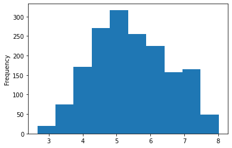

```python
df["Life Ladder"].plot(kind="hist")
```

Mit `bins` kann die Anzahl der Bins vorgeben werden.

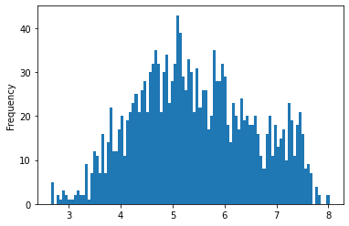

```python
df["Life Ladder"].plot(kind="hist", bins=100)
```

Eine glattere Verteilung ergibt die Einstellung `kind="density"`.

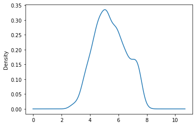

```python
df["Life Ladder"].plot(kind="density")
```

## Fehlende Werte

Der Datensatz hat insgesamt 1704 Zeilen. Die Anzahl der non-null Werte unterscheidet sich stark zwischen den Spalten. Es gibt viele Spalten mit fehlenden Werten, wie etwa "Most people can be trusted, WVS round 2005-2009". Die Methode `isnull()` hilft, fehlende Werte zu identifizieren und das Muster fehlender Werte weiter zu analysieren. Mit Hilfe von `any()` oder `sum()` kann eine Liste der Spalten mit fehlenden Werte erstellt bzw. die Anzahl der fehlenden Werte pro Spalte ermittelt werden.

```python
# Welche Spalten enhalten fehlende Werte
df.isnull().any()
```

```
Country name                                                False
Year                                                        False
Life Ladder                                                 False
Log GDP per capita                                           True
Social support                                               True
Healthy life expectancy at birth                             True
Freedom to make life choices                                 True
Generosity                                                   True
Perceptions of corruption                                    True
Positive affect                                              True
Negative affect                                              True
Confidence in national government                            True
Democratic Quality                                           True
Delivery Quality                                             True
Standard deviation of ladder by country-year                False
Standard deviation/Mean of ladder by country-year           False
GINI index (World Bank estimate)                             True
GINI index (World Bank estimate), average 2000-16            True
gini of household income reported in Gallup, by wp5-year     True
Most people can be trusted, Gallup                           True
Most people can be trusted, WVS round 1981-1984              True
Most people can be trusted, WVS round 1989-1993              True
Most people can be trusted, WVS round 1994-1998              True
Most people can be trusted, WVS round 1999-2004              True
Most people can be trusted, WVS round 2005-2009              True
Most people can be trusted, WVS round 2010-2014              True
dtype: bool
```

```python
# Anzahl der fehlenden Werte pro Spalte
df.isnull().sum()
```

```
Country name                                                   0
Year                                                           0
Life Ladder                                                    0
Log GDP per capita                                            28
Social support                                                13
Healthy life expectancy at birth                              28
Freedom to make life choices                                  29
Generosity                                                    82
Perceptions of corruption                                     96
Positive affect                                               19
Negative affect                                               13
Confidence in national government                            174
Democratic Quality                                           146
Delivery Quality                                             145
Standard deviation of ladder by country-year                   0
Standard deviation/Mean of ladder by country-year              0
GINI index (World Bank estimate)                            1061
GINI index (World Bank estimate), average 2000-16            202
gini of household income reported in Gallup, by wp5-year     369
Most people can be trusted, Gallup                          1524
Most people can be trusted, WVS round 1981-1984             1579
Most people can be trusted, WVS round 1989-1993             1484
Most people can be trusted, WVS round 1994-1998             1086
Most people can be trusted, WVS round 1999-2004             1213
Most people can be trusted, WVS round 2005-2009             1074
Most people can be trusted, WVS round 2010-2014             1033
dtype: int64
```

```python
# Liste der Spalten mit fehlenden Werten
df.isnull().any().index.to_list()
```

```
['Country name',
 'Year',
 'Life Ladder',
 'Log GDP per capita',
 'Social support',
 'Healthy life expectancy at birth',
 'Freedom to make life choices',
 'Generosity',
 'Perceptions of corruption',
 'Positive affect',
 'Negative affect',
 'Confidence in national government',
 'Democratic Quality',
 'Delivery Quality',
 'Standard deviation of ladder by country-year',
 'Standard deviation/Mean of ladder by country-year',
 'GINI index (World Bank estimate)',
 'GINI index (World Bank estimate), average 2000-16',
 'gini of household income reported in Gallup, by wp5-year',
 'Most people can be trusted, Gallup',
 'Most people can be trusted, WVS round 1981-1984',
 'Most people can be trusted, WVS round 1989-1993',
 'Most people can be trusted, WVS round 1994-1998',
 'Most people can be trusted, WVS round 1999-2004',
 'Most people can be trusted, WVS round 2005-2009',
 'Most people can be trusted, WVS round 2010-2014']
```

## Daten filtern

Einzelne Elemente eines Datensatzes können ausgewählt bzw. gefiltert werden.

```python
# Die Spalte Country name
df["Country name"]
```

```
0       Afghanistan
1       Afghanistan
2       Afghanistan
3       Afghanistan
4       Afghanistan
           ...
1699       Zimbabwe
1700       Zimbabwe
1701       Zimbabwe
1702       Zimbabwe
1703       Zimbabwe
Name: Country name, Length: 1704, dtype: object
```

```python
# Die Spalten Country Name und Year
# (mehrere Spalten müssen als Liste übergeben werden)
df[["Country name", "Year"]]
```

|  | Country name | Year |
| --- | --- | --- |
| 0 | Afghanistan | 2008 |
| 1 | Afghanistan | 2009 |
| 2 | Afghanistan | 2010 |
| 3 | Afghanistan | 2011 |
| 4 | Afghanistan | 2012 |
| ... | ... | ... |
| 1699 | Zimbabwe | 2014 |
| 1700 | Zimbabwe | 2015 |
| 1701 | Zimbabwe | 2016 |
| 1702 | Zimbabwe | 2017 |
| 1703 | Zimbabwe | 2018 |

1704 rows × 2 columns

Der Datensatz erhält pro Land mehrere Einträge, da es für jedes Land für mehrere Jahre Daten gibt. Mit der Funktion `unique()` können wir eine Liste der Länder erstellen.

```python
# Liste unterschiedlicher Einträge in der Spalte Country Name
df["Country name"].unique()
```

```
array(['Afghanistan', 'Albania', 'Algeria', 'Angola', 'Argentina',
       'Armenia', 'Australia', 'Austria', 'Azerbaijan', 'Bahrain',
       'Bangladesh', 'Belarus', 'Belgium', 'Belize', 'Benin', 'Bhutan',
       'Bolivia', 'Bosnia and Herzegovina', 'Botswana', 'Brazil',
       'Bulgaria', 'Burkina Faso', 'Burundi', 'Cambodia', 'Cameroon',
       'Canada', 'Central African Republic', 'Chad', 'Chile', 'China',
       'Colombia', 'Comoros', 'Congo (Brazzaville)', 'Congo (Kinshasa)',
       'Costa Rica', 'Croatia', 'Cuba', 'Cyprus', 'Czech Republic',
       'Denmark', 'Djibouti', 'Dominican Republic', 'Ecuador', 'Egypt',
       'El Salvador', 'Estonia', 'Ethiopia', 'Finland', 'France', 'Gabon',
       'Gambia', 'Georgia', 'Germany', 'Ghana', 'Greece', 'Guatemala',
       'Guinea', 'Guyana', 'Haiti', 'Honduras',
       'Hong Kong S.A.R. of China', 'Hungary', 'Iceland', 'India',
       'Indonesia', 'Iran', 'Iraq', 'Ireland', 'Israel', 'Italy',
       'Ivory Coast', 'Jamaica', 'Japan', 'Jordan', 'Kazakhstan', 'Kenya',
       'Kosovo', 'Kuwait', 'Kyrgyzstan', 'Laos', 'Latvia', 'Lebanon',
       'Lesotho', 'Liberia', 'Libya', 'Lithuania', 'Luxembourg',
       'Macedonia', 'Madagascar', 'Malawi', 'Malaysia', 'Mali', 'Malta',
       'Mauritania', 'Mauritius', 'Mexico', 'Moldova', 'Mongolia',
       'Montenegro', 'Morocco', 'Mozambique', 'Myanmar', 'Namibia',
       'Nepal', 'Netherlands', 'New Zealand', 'Nicaragua', 'Niger',
       'Nigeria', 'North Cyprus', 'Norway', 'Oman', 'Pakistan',
       'Palestinian Territories', 'Panama', 'Paraguay', 'Peru',
       'Philippines', 'Poland', 'Portugal', 'Qatar', 'Romania', 'Russia',
       'Rwanda', 'Saudi Arabia', 'Senegal', 'Serbia', 'Sierra Leone',
       'Singapore', 'Slovakia', 'Slovenia', 'Somalia',
       'Somaliland region', 'South Africa', 'South Korea', 'South Sudan',
       'Spain', 'Sri Lanka', 'Sudan', 'Suriname', 'Swaziland', 'Sweden',
       'Switzerland', 'Syria', 'Taiwan Province of China', 'Tajikistan',
       'Tanzania', 'Thailand', 'Togo', 'Trinidad and Tobago', 'Tunisia',
       'Turkey', 'Turkmenistan', 'Uganda', 'Ukraine',
       'United Arab Emirates', 'United Kingdom', 'United States',
       'Uruguay', 'Uzbekistan', 'Venezuela', 'Vietnam', 'Yemen', 'Zambia',
       'Zimbabwe'], dtype=object)
```

```python
# Anzahl unterschiedlicher Einträge in der Spalte Country Name
df["Country name"].nunique()
```

```
165
```

Wir können auf Bedingungen filtern. Die Bedingung steht in eckigen Klammern. Sie muss den vollständigen Namen (also Datensatz und Spaltennamen) beinhalten.

```python
df[df["Year"]>=2015]
```

|  | Country name | Year | Life Ladder | Log GDP per capita | Social support | Healthy life expectancy at birth | Freedom to make life choices | Generosity | Perceptions of corruption | Positive affect | ... | GINI index (World Bank estimate) | GINI index (World Bank estimate), average 2000-16 | gini of household income reported in Gallup, by wp5-year | Most people can be trusted, Gallup | Most people can be trusted, WVS round 1981-1984 | Most people can be trusted, WVS round 1989-1993 | Most people can be trusted, WVS round 1994-1998 | Most people can be trusted, WVS round 1999-2004 | Most people can be trusted, WVS round 2005-2009 | Most people can be trusted, WVS round 2010-2014 |
| --- | --- | --- | --- | --- | --- | --- | --- | --- | --- | --- | --- | --- | --- | --- | --- | --- | --- | --- | --- | --- | --- |
| 7 | Afghanistan | 2015 | 3.982855 | 7.500539 | 0.528597 | 53.200001 | 0.388928 | 0.089091 | 0.880638 | 0.553553 | ... | NaN | NaN | 0.596918 | NaN | NaN | NaN | NaN | NaN | NaN | NaN |
| 8 | Afghanistan | 2016 | 4.220169 | 7.497038 | 0.559072 | 53.000000 | 0.522566 | 0.051365 | 0.793246 | 0.564953 | ... | NaN | NaN | 0.418629 | NaN | NaN | NaN | NaN | NaN | NaN | NaN |
| 9 | Afghanistan | 2017 | 2.661718 | 7.497755 | 0.490880 | 52.799999 | 0.427011 | -0.112198 | 0.954393 | 0.496349 | ... | NaN | NaN | 0.286599 | NaN | NaN | NaN | NaN | NaN | NaN | NaN |
| 10 | Afghanistan | 2018 | 2.694303 | 7.494588 | 0.507516 | 52.599998 | 0.373536 | -0.084888 | 0.927606 | 0.424125 | ... | NaN | NaN | 0.290681 | NaN | NaN | NaN | NaN | NaN | NaN | NaN |
| 18 | Albania | 2015 | 4.606651 | 9.302960 | 0.639356 | 67.800003 | 0.703851 | -0.084411 | 0.884793 | 0.688370 | ... | NaN | 0.30325 | 0.422627 | NaN | NaN | NaN | 0.243243 | 0.232000 | NaN | NaN |
| ... | ... | ... | ... | ... | ... | ... | ... | ... | ... | ... | ... | ... | ... | ... | ... | ... | ... | ... | ... | ... | ... |
| 1690 | Zambia | 2018 | 4.041488 | 8.223958 | 0.717720 | 55.299999 | 0.790626 | 0.036644 | 0.810731 | 0.702698 | ... | NaN | 0.52740 | 0.619443 | NaN | NaN | NaN | NaN | NaN | 0.110429 | NaN |
| 1700 | Zimbabwe | 2015 | 3.703191 | 7.556052 | 0.735800 | 53.799999 | 0.667193 | -0.097354 | 0.810457 | 0.715079 | ... | NaN | 0.43200 | 0.655137 | NaN | NaN | NaN | NaN | 0.116683 | NaN | 0.082942 |
| 1701 | Zimbabwe | 2016 | 3.735400 | 7.538829 | 0.768425 | 54.400002 | 0.732971 | -0.068105 | 0.723612 | 0.737636 | ... | NaN | 0.43200 | 0.596690 | NaN | NaN | NaN | NaN | 0.116683 | NaN | 0.082942 |
| 1702 | Zimbabwe | 2017 | 3.638300 | 7.549491 | 0.754147 | 55.000000 | 0.752826 | -0.069670 | 0.751208 | 0.806428 | ... | NaN | 0.43200 | 0.581484 | NaN | NaN | NaN | NaN | 0.116683 | NaN | 0.082942 |
| 1703 | Zimbabwe | 2018 | 3.616480 | 7.553395 | 0.775388 | 55.599998 | 0.762675 | -0.038384 | 0.844209 | 0.710119 | ... | NaN | 0.43200 | 0.541772 | NaN | NaN | NaN | NaN | 0.116683 | NaN | 0.082942 |

568 rows × 26 columns

Es können auch mehrere Bedingungen kombiniert werden (|= OR, & = AND, ~ = Negation). Mehrere Bedingungen werden jeweils in runde Klammern eingeschlossen. Eine Auswahl der Spalten kann zusätzlich erfolgen. Da dies unübersichtlich werden kann, empfiehlt es sich die Bedingung separat zu definieren.

```python
# Filter definieren
DK_from_2015 = (df["Country name"]=="Denmark") & (df["Year"]>=2015)
# Filter anwenden und Spalten auswählen
df[["Country name", "Year", "Life Ladder"]][DK_from_2015]
```

|  | Country name | Year | Life Ladder |
| --- | --- | --- | --- |
| 406 | Denmark | 2015 | 7.514425 |
| 407 | Denmark | 2016 | 7.557783 |
| 408 | Denmark | 2017 | 7.593702 |
| 409 | Denmark | 2018 | 7.648786 |

Mit `isin()` können wir auch Filter erstellen, die prüfen ob ein Element zu einer Gruppe gehört.

```python
# Filter definieren
# Skandinavien
scandinavia = ["Denmark", "Norway", "Sweden"]
only_scandinavia = df["Country name"].isin(scandinavia)
# Nur 2018
only_2018 = df["Year"]==2018
# Filtern anwenden und Spalten auswählen
df[["Country name", "Year", "Life Ladder"]][only_scandinavia & only_2018]
```

|  | Country name | Year | Life Ladder |
| --- | --- | --- | --- |
| 409 | Denmark | 2018 | 7.648786 |
| 1139 | Norway | 2018 | 7.444262 |
| 1444 | Sweden | 2018 | 7.374792 |

## Re-Kodierung: neue kategorische Variablen bilden

### Neue kategorische Variable als Hierarchie

Im folgenden wollen wir uns auf einige europäische Länder begrenzen. Wir filtern den Datensatz entsprechend. Dazu erstellen wir zunächst eine neue Variable "Country Group", die verschiedene Länder in Ländergruppen zusammenfasst. Wir bilden also eine Hierarchie. Nachdem wir diese neue kategorische Variable gebildet haben, können wir uns mit `value_counts()` die Einträge pro Ausprägung angucken.

```python
# Ländergruppen definieren
western_europe = ["Austria", "Belgium", "Denmark", "Finland", "France", "Germany", "Greece", "Ireland", "Italy", "Luxembourg", "Netherlands", "Norway", "Portugal", "Romania", "Spain", "Sweden", "Switzerland", "United Kingdom"]
eastern_europe = ["Bosnia and Herzegovina", "Croatia", "Cyprus", "Czech Republic", "Estonia", "Hungary", "Latvia", "Lithuania", "Malta", "Poland", "Serbia", "Slovakia", "Slovenia"]

# Filter definieren
western_europe_fltr = df["Country name"].isin(western_europe)
eastern_europe_fltr = df["Country name"].isin(eastern_europe)

# Neue Spalte mit Ländergruppen hinzufügen
df["Country group"]=np.NaN
df["Country group"] [western_europe_fltr] = "Western Europe"
df["Country group"] [eastern_europe_fltr] = "Eastern Europe"

# Anzahl der Reihen pro Kategorie (inkl. fehlender Werte)
df["Country group"].value_counts(dropna=False)
```

```
NaN               1349
Western Europe     210
Eastern Europe     145
Name: Country group, dtype: int64
```

Es gibt 355 Einträge für europäische Ländern.

```python
europe_fltr = df["Country group"].isin(["Western Europe", "Eastern Europe"])
df_europe = df[europe_fltr]
df_europe.shape
```

```
(355, 27)
```

Unser neuer Datensatz df_europe hat 355 Zeilen.

```python
# Länder in dem kleineren Datensatz
df_europe["Country name"].unique()
```

```
array(['Austria', 'Belgium', 'Bosnia and Herzegovina', 'Croatia',
       'Cyprus', 'Czech Republic', 'Denmark', 'Estonia', 'Finland',
       'France', 'Germany', 'Greece', 'Hungary', 'Ireland', 'Italy',
       'Latvia', 'Lithuania', 'Luxembourg', 'Malta', 'Netherlands',
       'Norway', 'Poland', 'Portugal', 'Romania', 'Serbia', 'Slovakia',
       'Slovenia', 'Spain', 'Sweden', 'Switzerland', 'United Kingdom'],
      dtype=object)
```

### Binning

Pandas hat zwei Methoden, um eine numerische Variable in mehrere Kategorien einzuteilen (**binning**). Mit Hilfe von `cut()` können die Kategorien selbst definiert werden. `qcut()` teilt eine numerische Variable in eine vorgegebene Anzahl gleich großer Kategorien auf.

Der Datensatz enthält eine Variable zur Lebenswertung. Mit `plot` können wir uns die Verteilung angucken.

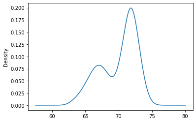

```python
df_europe["Healthy life expectancy at birth"].plot(kind="density")
```

Für eine Auswertung sind die spezifischen Werte vielleicht nicht so relevant, so dass man auch eine übersichtliche Anzahl an Kategorien betrachten kann. Wenn man keine inhaltliche Gründe für eine bestimmte Aufteilung kennt, dann bietet es sich an, einfach gleich große Gruppen zu bilden.

```python
df_europe["Healthy life expectancy at birth"].describe()
```

```
count    355.000000
mean      70.005746
std        2.708642
min       63.139999
25%       67.689999
50%       71.080002
75%       72.099998
max       74.400002
Name: Healthy life expectancy at birth, dtype: float64
```

Mit der Methode `qcut()` können wir auf Grundlager der numerischen Variable "Healthy life expectancy at birth" eine kategorische Variablen mit einer vorgegebenen Anzahl gleich großer Kategorien bilden. Bei vier Kategorien werden dann Gruppen entsprechend der Quartile gebildet. Die Anzahl der Kategorien wird über den Parameter `q` gesteuert.

```python
# Neue kategorische Variablen mit Quartilen der Lebenserwartung bilden
df_europe["Life expectancy (quartiles)"] = pd.qcut(df_europe["Healthy life expectancy at birth"], q=4)
df_europe["Life expectancy (quartiles)"]
```

```
71      (67.69, 71.08]
72      (67.69, 71.08]
73       (71.08, 72.1]
74       (71.08, 72.1]
75       (71.08, 72.1]
             ...
1599     (71.08, 72.1]
1600     (71.08, 72.1]
1601     (71.08, 72.1]
1602     (71.08, 72.1]
1603      (72.1, 74.4]
Name: Life expectancy (quartiles), Length: 355, dtype: category
Categories (4, interval[float64]): [(63.139, 67.69] < (67.69, 71.08] < (71.08, 72.1] < (72.1, 74.4]]
```

MIt Hilfe von `value_counts()` können wir uns davon überzeugen, dass die Kategorien (fast) genau gleich groß sind.

```python
df_europe["Life expectancy (quartiles)"].value_counts()
```

```
(71.08, 72.1]      92
(63.139, 67.69]    89
(67.69, 71.08]     89
(72.1, 74.4]       85
Name: Life expectancy (quartiles), dtype: int64
```

Die Methode bildet halb-offene Intervalle, die standardmäßig auch als Namen der Kategorien benutzt werden. Man kann mittels des Parameters `label` auch eine eigene Liste von Namen vergeben.

```python
life_exp_quart_labs = ["1. Quartile", "2. Quartile", "3. Quartile", "4. Quartile"]
df_europe["Life expectancy (quartiles)"] = pd.qcut(df_europe["Healthy life expectancy at birth"], q=4, labels=life_exp_quart_labs)
df_europe["Life expectancy (quartiles)"]
```

```
71      2. Quartile
72      2. Quartile
73      3. Quartile
74      3. Quartile
75      3. Quartile
           ...
1599    3. Quartile
1600    3. Quartile
1601    3. Quartile
1602    3. Quartile
1603    4. Quartile
Name: Life expectancy (quartiles), Length: 355, dtype: category
Categories (4, object): ['1. Quartile' < '2. Quartile' < '3. Quartile' < '4. Quartile']
```

```python
df_europe["Life expectancy (quartiles)"].value_counts()
```

```
3. Quartile    92
1. Quartile    89
2. Quartile    89
4. Quartile    85
Name: Life expectancy (quartiles), dtype: int64
```

```python
df_europe["Life expectancy (quartiles)"].describe(include="category")
```

```
count             355
unique              4
top       3. Quartile
freq               92
Name: Life expectancy (quartiles), dtype: object
```

Wir begrenzen den Datensatz zusätzlich noch auf bestimmte Spalten. Die Variable "Life Ladder" bezieht sich auf das subjektive Wohlergehen. Wir ändern den Namen der Spalten dementsprechend.

```python
selected_columns = ["Country name", "Country group", "Year", "Life Ladder", "Positive affect", "Life expectancy (quartiles)", "Log GDP per capita", "Democratic Quality"]
df_europe = df_europe[selected_columns]
df_europe.rename(columns = {'Life Ladder':'Subjective Wellbeing'}, inplace = True)
df_europe.info()
```

```
<class 'pandas.core.frame.DataFrame'>
Int64Index: 355 entries, 71 to 1603
Data columns (total 8 columns):
 #   Column                       Non-Null Count  Dtype
---  ------                       --------------  -----
 0   Country name                 355 non-null    object
 1   Country group                355 non-null    object
 2   Year                         355 non-null    int64
 3   Subjective Wellbeing         355 non-null    float64
 4   Positive affect              355 non-null    float64
 5   Life expectancy (quartiles)  355 non-null    category
 6   Log GDP per capita           353 non-null    float64
 7   Democratic Quality           326 non-null    float64
dtypes: category(1), float64(4), int64(1), object(2)
memory usage: 22.7+ KB
```

Die Spalte für Democratic Quality hat fehlende Werte. Wir können uns die Ländernamen und Jahre für die Zeilen mit fehlenden Werten ausgeben lassen.

```python
row_with_missing_data = df_europe.isnull().any(axis=1)
df_europe[["Country name", "Year"]][row_with_missing_data]
```

|  | Country name | Year |
| --- | --- | --- |
| 81 | Austria | 2018 |
| 141 | Belgium | 2018 |
| 180 | Bosnia and Herzegovina | 2018 |
| 373 | Croatia | 2018 |
| 385 | Cyprus | 2018 |
| 396 | Czech Republic | 2018 |
| 409 | Denmark | 2018 |
| 477 | Estonia | 2018 |
| 495 | Finland | 2018 |
| 508 | France | 2018 |
| 544 | Germany | 2018 |
| 568 | Greece | 2018 |
| 699 | Ireland | 2018 |
| 725 | Italy | 2018 |
| 843 | Latvia | 2018 |
| 885 | Lithuania | 2018 |
| 895 | Luxembourg | 2018 |
| 960 | Malta | 2018 |
| 1076 | Netherlands | 2018 |
| 1139 | Norway | 2018 |
| 1239 | Portugal | 2018 |
| 1256 | Romania | 2018 |
| 1317 | Serbia | 2018 |
| 1350 | Slovakia | 2018 |
| 1361 | Slovenia | 2018 |
| 1411 | Spain | 2018 |
| 1444 | Sweden | 2018 |
| 1452 | Switzerland | 2018 |
| 1603 | United Kingdom | 2018 |

Anscheinend fehlt diese Information für ein ganzes Jahr. Um diese Vermutung zu bestätigen, lassen wir uns die verschiedenen Werte für 2018 ausgeben.

```python
df_europe[df_europe["Year"] == 2018]["Democratic Quality"].unique()
```

```
array([nan])
```

Zuletzt speichern wir den kleineren und um die Region (Country group) sowie die kategorische Variable Life expectancy (quartiles) angereicherten Datensatz als CSV-Datei ab. Standardmässig wird ein Komma als Trennzeichen verwendet.

```python
df_europe.to_csv("WHR2019_Chapter2OnlineData_Europe.csv")
```

In dem zweiten Teil arbeiten wir mit den Daten für Europa weiter und betrachten einige (teilweise aggregierte) deskriptive Statistiken. Wir gucken uns auch einige bi-variate Zusammenhänge mit Hilfe von Datenvisualisierungen an. Schließlich rechnen wir eine einfache Regressionsanalyse.